# Loan Data from Prosper

## Preliminary Wrangling

> Over 113K loan records from Prosper, a peer-to-peer lending marketplace

```python
# import all packages and set plots to be embedded inline
import numpy as np
import pandas as pd
import matplotlib.pyplot as plt
import seaborn as sb

%matplotlib inline
```

```python
# loading dataset by reading csv file
loans = pd.read_csv('prosperLoanData.csv')
```

## Clickable Index

Univariate Exploration

Bivariate Exploration

Multivariate Exploration

```python
loans.tail()
```

|  | ListingKey | ListingNumber | ListingCreationDate | CreditGrade | Term | LoanStatus | ClosedDate | BorrowerAPR | BorrowerRate | LenderYield | ... | LP_ServiceFees | LP_CollectionFees | LP_GrossPrincipalLoss | LP_NetPrincipalLoss | LP_NonPrincipalRecoverypayments | PercentFunded | Recommendations | InvestmentFromFriendsCount | InvestmentFromFriendsAmount | Investors |
| --- | --- | --- | --- | --- | --- | --- | --- | --- | --- | --- | --- | --- | --- | --- | --- | --- | --- | --- | --- | --- | --- |
| 113932 | E6D9357655724827169606C | 753087 | 2013-04-14 05:55:02.663000000 | NaN | 36 | Current | NaN | 0.22354 | 0.1864 | 0.1764 | ... | -75.58 | 0.0 | 0.0 | 0.0 | 0.0 | 1.0 | 0 | 0 | 0.0 | 1 |
| 113933 | E6DB353036033497292EE43 | 537216 | 2011-11-03 20:42:55.333000000 | NaN | 36 | FinalPaymentInProgress | NaN | 0.13220 | 0.1110 | 0.1010 | ... | -30.05 | 0.0 | 0.0 | 0.0 | 0.0 | 1.0 | 0 | 0 | 0.0 | 22 |
| 113934 | E6E13596170052029692BB1 | 1069178 | 2013-12-13 05:49:12.703000000 | NaN | 60 | Current | NaN | 0.23984 | 0.2150 | 0.2050 | ... | -16.91 | 0.0 | 0.0 | 0.0 | 0.0 | 1.0 | 0 | 0 | 0.0 | 119 |
| 113935 | E6EB3531504622671970D9E | 539056 | 2011-11-14 13:18:26.597000000 | NaN | 60 | Completed | 2013-08-13 00:00:00 | 0.28408 | 0.2605 | 0.2505 | ... | -235.05 | 0.0 | 0.0 | 0.0 | 0.0 | 1.0 | 0 | 0 | 0.0 | 274 |
| 113936 | E6ED3600409833199F711B7 | 1140093 | 2014-01-15 09:27:37.657000000 | NaN | 36 | Current | NaN | 0.13189 | 0.1039 | 0.0939 | ... | -1.70 | 0.0 | 0.0 | 0.0 | 0.0 | 1.0 | 0 | 0 | 0.0 | 1 |

5 rows × 81 columns

```python
loans.info()
```

```
<class 'pandas.core.frame.DataFrame'>
RangeIndex: 113937 entries, 0 to 113936
Data columns (total 81 columns):
ListingKey                             113937 non-null object
ListingNumber                          113937 non-null int64
ListingCreationDate                    113937 non-null object
CreditGrade                            28953 non-null object
Term                                   113937 non-null int64
LoanStatus                             113937 non-null object
ClosedDate                             55089 non-null object
BorrowerAPR                            113912 non-null float64
BorrowerRate                           113937 non-null float64
LenderYield                            113937 non-null float64
EstimatedEffectiveYield                84853 non-null float64
EstimatedLoss                          84853 non-null float64
EstimatedReturn                        84853 non-null float64
ProsperRating (numeric)                84853 non-null float64
ProsperRating (Alpha)                  84853 non-null object
ProsperScore                           84853 non-null float64
ListingCategory (numeric)              113937 non-null int64
BorrowerState                          108422 non-null object
Occupation                             110349 non-null object
EmploymentStatus                       111682 non-null object
EmploymentStatusDuration               106312 non-null float64
IsBorrowerHomeowner                    113937 non-null bool
CurrentlyInGroup                       113937 non-null bool
GroupKey                               13341 non-null object
DateCreditPulled                       113937 non-null object
CreditScoreRangeLower                  113346 non-null float64
CreditScoreRangeUpper                  113346 non-null float64
FirstRecordedCreditLine                113240 non-null object
CurrentCreditLines                     106333 non-null float64
OpenCreditLines                        106333 non-null float64
TotalCreditLinespast7years             113240 non-null float64
OpenRevolvingAccounts                  113937 non-null int64
OpenRevolvingMonthlyPayment            113937 non-null float64
InquiriesLast6Months                   113240 non-null float64
TotalInquiries                         112778 non-null float64
CurrentDelinquencies                   113240 non-null float64
AmountDelinquent                       106315 non-null float64
```

[output cut: 31 more lines]

```
LP_CustomerPayments                    113937 non-null float64
LP_CustomerPrincipalPayments           113937 non-null float64
LP_InterestandFees                     113937 non-null float64
LP_ServiceFees                         113937 non-null float64
LP_CollectionFees                      113937 non-null float64
LP_GrossPrincipalLoss                  113937 non-null float64
LP_NetPrincipalLoss                    113937 non-null float64
LP_NonPrincipalRecoverypayments        113937 non-null float64
PercentFunded                          113937 non-null float64
Recommendations                        113937 non-null int64
InvestmentFromFriendsCount             113937 non-null int64
InvestmentFromFriendsAmount            113937 non-null float64
Investors                              113937 non-null int64
dtypes: bool(3), float64(50), int64(11), object(17)
memory usage: 68.1+ MB
```

```python
loans.describe()
```

|  | ListingNumber | Term | BorrowerAPR | BorrowerRate | LenderYield | EstimatedEffectiveYield | EstimatedLoss | EstimatedReturn | ProsperRating (numeric) | ProsperScore | ... | LP_ServiceFees | LP_CollectionFees | LP_GrossPrincipalLoss | LP_NetPrincipalLoss | LP_NonPrincipalRecoverypayments | PercentFunded | Recommendations | InvestmentFromFriendsCount | InvestmentFromFriendsAmount | Investors |
| --- | --- | --- | --- | --- | --- | --- | --- | --- | --- | --- | --- | --- | --- | --- | --- | --- | --- | --- | --- | --- | --- |
| count | 1.139370e+05 | 113937.000000 | 113912.000000 | 113937.000000 | 113937.000000 | 84853.000000 | 84853.000000 | 84853.000000 | 84853.000000 | 84853.000000 | ... | 113937.000000 | 113937.000000 | 113937.000000 | 113937.000000 | 113937.000000 | 113937.000000 | 113937.000000 | 113937.000000 | 113937.000000 | 113937.000000 |
| mean | 6.278857e+05 | 40.830248 | 0.218828 | 0.192764 | 0.182701 | 0.168661 | 0.080306 | 0.096068 | 4.072243 | 5.950067 | ... | -54.725641 | -14.242698 | 700.446342 | 681.420499 | 25.142686 | 0.998584 | 0.048027 | 0.023460 | 16.550751 | 80.475228 |
| std | 3.280762e+05 | 10.436212 | 0.080364 | 0.074818 | 0.074516 | 0.068467 | 0.046764 | 0.030403 | 1.673227 | 2.376501 | ... | 60.675425 | 109.232758 | 2388.513831 | 2357.167068 | 275.657937 | 0.017919 | 0.332353 | 0.232412 | 294.545422 | 103.239020 |
| min | 4.000000e+00 | 12.000000 | 0.006530 | 0.000000 | -0.010000 | -0.182700 | 0.004900 | -0.182700 | 1.000000 | 1.000000 | ... | -664.870000 | -9274.750000 | -94.200000 | -954.550000 | 0.000000 | 0.700000 | 0.000000 | 0.000000 | 0.000000 | 1.000000 |
| 25% | 4.009190e+05 | 36.000000 | 0.156290 | 0.134000 | 0.124200 | 0.115670 | 0.042400 | 0.074080 | 3.000000 | 4.000000 | ... | -73.180000 | 0.000000 | 0.000000 | 0.000000 | 0.000000 | 1.000000 | 0.000000 | 0.000000 | 0.000000 | 2.000000 |
| 50% | 6.005540e+05 | 36.000000 | 0.209760 | 0.184000 | 0.173000 | 0.161500 | 0.072400 | 0.091700 | 4.000000 | 6.000000 | ... | -34.440000 | 0.000000 | 0.000000 | 0.000000 | 0.000000 | 1.000000 | 0.000000 | 0.000000 | 0.000000 | 44.000000 |
| 75% | 8.926340e+05 | 36.000000 | 0.283810 | 0.250000 | 0.240000 | 0.224300 | 0.112000 | 0.116600 | 5.000000 | 8.000000 | ... | -13.920000 | 0.000000 | 0.000000 | 0.000000 | 0.000000 | 1.000000 | 0.000000 | 0.000000 | 0.000000 | 115.000000 |
| max | 1.255725e+06 | 60.000000 | 0.512290 | 0.497500 | 0.492500 | 0.319900 | 0.366000 | 0.283700 | 7.000000 | 11.000000 | ... | 32.060000 | 0.000000 | 25000.000000 | 25000.000000 | 21117.900000 | 1.012500 | 39.000000 | 33.000000 | 25000.000000 | 1189.000000 |

8 rows × 61 columns

### What is the structure of your dataset?

> There are 113937 loan listings in the dataset, with 81 features, listed between 2005 and 2014. Most features are numeric or strings, but there are some datetime and categorical type columns that may need converting.

### What is/are the main feature(s) of interest in your dataset?

> I'm interested in finding out how borrowing from friends influence on one's default rate.

> `update` It turns out too few of the loans were funded by 5 friends or more (only 26), so we'll try to determine what factors have influence on the default rate (LoanStatus) and BorrowerAPR.

### What features in the dataset do you think will help support your investigation into your feature(s) of interest?

> The latter columns (InvestmentFromFriendsCount and InvestmentFromFriendsAmount) would be of particular interest if we were to maintain our initial interest to investigate the correlation between being funded by friends and one's default rate. Since that is no longer the case, we expect the following to have some relation to LoanStatus:
> - BorrowerAPR,
> - EmploymentStatus,
> - DebtToIncomeRatio and
> - IncomeRange

## Univariate Exploration

```python
# checking format of date columns

loans.DateCreditPulled.head()
```

```
0    2007-08-26 18:41:46.780000000
1              2014-02-27 08:28:14
2    2007-01-02 14:09:10.060000000
3              2012-10-22 11:02:32
4              2013-09-14 18:38:44
Name: DateCreditPulled, dtype: object
```

```python
# converting date columns

date_columns = ['DateCreditPulled', 'ClosedDate', 'LoanOriginationDate', 'ListingCreationDate']

for date_column in date_columns:
    loans[date_column] = pd.to_datetime(loans[date_column], infer_datetime_format=True)
loans.info()
```

```
<class 'pandas.core.frame.DataFrame'>
RangeIndex: 113937 entries, 0 to 113936
Data columns (total 81 columns):
ListingKey                             113937 non-null object
ListingNumber                          113937 non-null int64
ListingCreationDate                    113937 non-null datetime64[ns]
CreditGrade                            28953 non-null object
Term                                   113937 non-null int64
LoanStatus                             113937 non-null object
ClosedDate                             55089 non-null datetime64[ns]
BorrowerAPR                            113912 non-null float64
BorrowerRate                           113937 non-null float64
LenderYield                            113937 non-null float64
EstimatedEffectiveYield                84853 non-null float64
EstimatedLoss                          84853 non-null float64
EstimatedReturn                        84853 non-null float64
ProsperRating (numeric)                84853 non-null float64
ProsperRating (Alpha)                  84853 non-null object
ProsperScore                           84853 non-null float64
ListingCategory (numeric)              113937 non-null int64
BorrowerState                          108422 non-null object
Occupation                             110349 non-null object
EmploymentStatus                       111682 non-null object
EmploymentStatusDuration               106312 non-null float64
IsBorrowerHomeowner                    113937 non-null bool
CurrentlyInGroup                       113937 non-null bool
GroupKey                               13341 non-null object
DateCreditPulled                       113937 non-null datetime64[ns]
CreditScoreRangeLower                  113346 non-null float64
CreditScoreRangeUpper                  113346 non-null float64
FirstRecordedCreditLine                113240 non-null object
CurrentCreditLines                     106333 non-null float64
OpenCreditLines                        106333 non-null float64
TotalCreditLinespast7years             113240 non-null float64
OpenRevolvingAccounts                  113937 non-null int64
OpenRevolvingMonthlyPayment            113937 non-null float64
InquiriesLast6Months                   113240 non-null float64
TotalInquiries                         112778 non-null float64
CurrentDelinquencies                   113240 non-null float64
AmountDelinquent                       106315 non-null float64
```

[output cut: 31 more lines]

```
LP_CustomerPayments                    113937 non-null float64
LP_CustomerPrincipalPayments           113937 non-null float64
LP_InterestandFees                     113937 non-null float64
LP_ServiceFees                         113937 non-null float64
LP_CollectionFees                      113937 non-null float64
LP_GrossPrincipalLoss                  113937 non-null float64
LP_NetPrincipalLoss                    113937 non-null float64
LP_NonPrincipalRecoverypayments        113937 non-null float64
PercentFunded                          113937 non-null float64
Recommendations                        113937 non-null int64
InvestmentFromFriendsCount             113937 non-null int64
InvestmentFromFriendsAmount            113937 non-null float64
Investors                              113937 non-null int64
dtypes: bool(3), datetime64[ns](4), float64(50), int64(11), object(13)
memory usage: 68.1+ MB
```

```python
loans.IncomeRange.value_counts()
```

```
$25,000-49,999    32192
$50,000-74,999    31050
$100,000+         17337
$75,000-99,999    16916
Not displayed      7741
$1-24,999          7274
Not employed        806
$0                  621
Name: IncomeRange, dtype: int64
```

```python
loans.IncomeRange.describe()
```

```
count             113937
unique                 8
top       $25,000-49,999
freq               32192
Name: IncomeRange, dtype: object
```

```python
loans.LoanStatus.value_counts()
```

```
Current                   56576
Completed                 38074
Chargedoff                11992
Defaulted                  5018
Past Due (1-15 days)        806
Past Due (31-60 days)       363
Past Due (61-90 days)       313
Past Due (91-120 days)      304
Past Due (16-30 days)       265
FinalPaymentInProgress      205
Past Due (>120 days)         16
Cancelled                     5
Name: LoanStatus, dtype: int64
```

```python
loans.LoanStatus.value_counts().index[::-1]
```

```
Index(['Cancelled', 'Past Due (>120 days)', 'FinalPaymentInProgress',
       'Past Due (16-30 days)', 'Past Due (91-120 days)',
       'Past Due (61-90 days)', 'Past Due (31-60 days)',
       'Past Due (1-15 days)', 'Defaulted', 'Chargedoff', 'Completed',
       'Current'],
      dtype='object')
```

```python
loans[loans.LoanStatus.isin(['Defaulted', 'Chargedoff'])].shape
```

```
(17010, 81)
```

```python
_[0]/loans.shape[0]
```

```
0.14929303035888253
```

> We have 15% defaulted or chargedoff loans in the dataset.

```python
# checking date range for loans

loans.ListingCreationDate.describe()
```

```
count                         113937
unique                        113064
top       2013-10-02 17:20:16.550000
freq                               6
first     2005-11-09 20:44:28.847000
last      2014-03-10 12:20:53.760000
Name: ListingCreationDate, dtype: object
```

```python
loans.EmploymentStatus.value_counts().index[::-1]
```

```
Index(['Retired', 'Not employed', 'Part-time', 'Other', 'Not available',
       'Self-employed', 'Full-time', 'Employed'],
      dtype='object')
```

> Categorical ordered columns of interest: IncomeRange, LoanStatus, EmploymentStatus

### Converting to ordered Categorical dtype

```python
cat_order = {'IncomeRange': ['Not displayed', 'Not employed', '$0', '$1-24,999', '$25,000-49,999',
                             '$50,000-74,999', '$75,000-99,999', '$100,000+'],
            'LoanStatus': ['Cancelled', 'Past Due (>120 days)', 'FinalPaymentInProgress', 'Past Due (16-30 days)',
                           'Past Due (91-120 days)', 'Past Due (61-90 days)', 'Past Due (31-60 days)',
                           'Past Due (1-15 days)', 'Defaulted', 'Chargedoff', 'Completed', 'Current'],
            'EmploymentStatus': ['Other', 'Not available', 'Not employed', 'Part-time', 'Self-employed',
                                 'Full-time', 'Employed', 'Retired']}
"""for column in cat_order:
    print(column)"""


for column in cat_order:
    ordered_var = pd.api.types.CategoricalDtype(ordered=True, categories=cat_order[column])
    loans[column] = loans[column].astype(ordered_var)
```

### Testing categorical

```python
loans[['IncomeRange', 'LoanStatus', 'EmploymentStatus']].info()
```

```
<class 'pandas.core.frame.DataFrame'>
RangeIndex: 113937 entries, 0 to 113936
Data columns (total 3 columns):
IncomeRange         113937 non-null category
LoanStatus          113937 non-null category
EmploymentStatus    111682 non-null category
dtypes: category(3)
memory usage: 335.0 KB
```

```python
loans.IncomeRange.dtype
```

```
CategoricalDtype(categories=['Not displayed', 'Not employed', '$0', '$1-24,999',
                  '$25,000-49,999', '$50,000-74,999', '$75,000-99,999',
                  '$100,000+'],
                 ordered=True)
```

### Checking Borrower APR dist

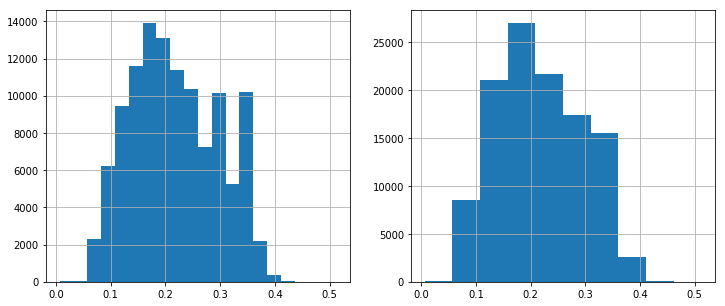

```python
# annual Borrower interest rates distribution
plt.figure(figsize=[12,5])

# trying different bins on subplots
plt.subplot(1,2,1)
loans.BorrowerAPR.hist(bins=20)

plt.subplot(1,2,2)
loans.BorrowerAPR.hist()
```

> Trying out different bin sizes, we can observe a bit more detail on the left chart. We can see that the mode is around 0.17 on a relatively normal, though narrow, distribution, with peaks also on 0.3 and around 0.35. The dist is slightly skewed to the right.
> - Later we'll check if Borrower APR is correlated to default.

### Checking percentage funded

- (actually, it looks like it is *proportion* funded)

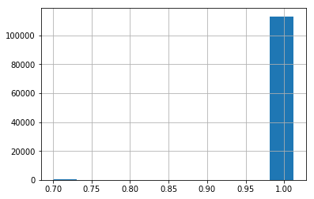

```python
loans['PercentFunded'].hist()
```

> Since distribution is highly skewed to the left, I'll try a log scale on y axis

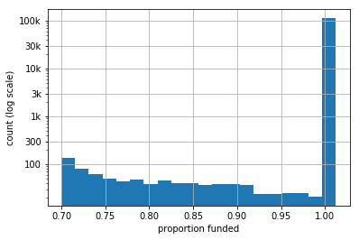

```python
loans.PercentFunded.hist(bins=20)
plt.yscale('log')
#plt.xscale('log')
y_ticks = [100, 300, 1000, 3000, 10000, 30000, 100000]
y_labels = ['100', '300', '1k', '3k', '10k', '30k', '100k']
plt.yticks(y_ticks, y_labels)
plt.ylabel('count (log scale)')
plt.xlabel('proportion funded');
```

> We can observe that more than 100k loans out of the 113k total have been fully funded.
> - Is employment status or the listing category mostly correlated to the probability of being fully funded on one's loan listing?

### Checking MemberKey

> Just to have an idea of unique borrowers on the dataset

```python
# So only 90K loans are from unique borrowers
loans.MemberKey.nunique()
```

```
90831
```

```python
loans.MemberKey.nunique()/loans.shape[0]
```

```
0.7972037178440717
```

> 79.72% of the listed loans are from unique borrowers, so a little over 20% are returning customers.
> - *Are the best-performing or the worst-performing returning?*

### Investment from Friends

> Our initial idea was to check whether being funded by friends had an impact on one's default rate

```python
loans.InvestmentFromFriendsCount.describe()
```

```
count    113937.000000
mean          0.023460
std           0.232412
min           0.000000
25%           0.000000
50%           0.000000
75%           0.000000
max          33.000000
Name: InvestmentFromFriendsCount, dtype: float64
```

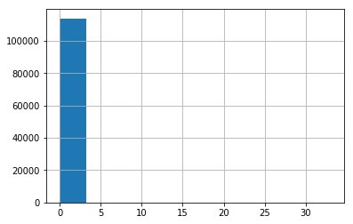

```python
loans.InvestmentFromFriendsCount.hist()
```

```python
loans[loans['InvestmentFromFriendsCount'] >= 5]
```

|  | ListingKey | ListingNumber | ListingCreationDate | CreditGrade | Term | LoanStatus | ClosedDate | BorrowerAPR | BorrowerRate | LenderYield | ... | LP_ServiceFees | LP_CollectionFees | LP_GrossPrincipalLoss | LP_NetPrincipalLoss | LP_NonPrincipalRecoverypayments | PercentFunded | Recommendations | InvestmentFromFriendsCount | InvestmentFromFriendsAmount | Investors |
| --- | --- | --- | --- | --- | --- | --- | --- | --- | --- | --- | --- | --- | --- | --- | --- | --- | --- | --- | --- | --- | --- |
| 4470 | 30193394811321396D90EC5 | 171459 | 2007-07-18 02:03:54.467 | C | 36 | Chargedoff | 2009-07-02 | 0.09939 | 0.0925 | 0.0825 | ... | -295.95 | -13.75 | 13375.17 | 13375.17 | 0.00 | 1.0 | 9 | 9 | 12459.55 | 93 |
| 14716 | 9A8434160319414122B8E0C | 301325 | 2008-03-29 10:32:51.860 | AA | 36 | Completed | 2011-02-07 | 0.05672 | 0.0500 | 0.0500 | ... | 0.00 | 0.00 | 0.00 | 0.00 | 0.00 | 1.0 | 39 | 33 | 23699.52 | 90 |
| 15545 | D4463388295350470A50968 | 132516 | 2007-05-04 00:01:08.887 | AA | 36 | Completed | 2010-03-16 | 0.08483 | 0.0780 | 0.0730 | ... | -93.85 | 0.00 | 0.00 | 0.00 | 0.00 | 1.0 | 21 | 20 | 6261.28 | 226 |
| 17717 | D05234067009139905384E0 | 236080 | 2007-11-23 02:12:10.157 | AA | 36 | Completed | 2010-11-10 | 0.07178 | 0.0650 | 0.0650 | ... | 0.00 | 0.00 | 0.00 | 0.00 | 0.00 | 1.0 | 16 | 15 | 5025.37 | 226 |
| 23147 | 68BE3430275694781B5F470 | 395966 | 2008-09-10 10:24:41.930 | AA | 36 | Completed | 2009-07-16 | 0.07580 | 0.0690 | 0.0590 | ... | -58.64 | 0.00 | 0.00 | 0.00 | 0.00 | 1.0 | 2 | 5 | 475.27 | 359 |
| 32063 | 3CA93460550792517A32417 | 420076 | 2009-08-10 12:52:23.120 | NaN | 36 | Completed | 2012-03-30 | 0.27904 | 0.2559 | 0.2459 | ... | -114.61 | 0.00 | 0.00 | 0.00 | 0.00 | 1.0 | 5 | 6 | 1430.00 | 73 |
| 50340 | 58E13410981598681A5DF60 | 272047 | 2008-01-27 10:54:33.170 | AA | 36 | Completed | 2010-01-15 | 0.09688 | 0.0900 | 0.0900 | ... | 0.00 | 0.00 | 0.00 | 0.00 | 0.00 | 1.0 | 14 | 13 | 7388.36 | 567 |
| 52890 | 5BB633982112627738EF19D | 187112 | 2007-08-14 13:01:57.240 | AA | 36 | Completed | 2009-03-20 | 0.08634 | 0.0795 | 0.0745 | ... | -132.22 | 0.00 | 0.00 | 0.00 | 0.00 | 1.0 | 8 | 8 | 12022.32 | 172 |
| 54760 | FF4034053057181163C6BFD | 233756 | 2007-11-18 14:34:29.867 | AA | 36 | Completed | 2009-05-06 | 0.07630 | 0.0695 | 0.0695 | ... | 0.00 | 0.00 | 0.00 | 0.00 | 0.00 | 1.0 | 9 | 9 | 5712.15 | 76 |
| 60934 | BE8A340462048538177C357 | 233764 | 2007-11-18 14:44:00.700 | AA | 36 | Completed | 2010-11-27 | 0.05672 | 0.0500 | 0.0500 | ... | 0.00 | 0.00 | 0.00 | 0.00 | 0.00 | 1.0 | 9 | 6 | 3550.00 | 67 |
| 62664 | 83343393410481420A567DB | 159598 | 2007-06-28 00:35:17.313 | AA | 36 | Completed | 2009-05-26 | 0.08684 | 0.0800 | 0.0750 | ... | -98.01 | 0.00 | 0.00 | 0.00 | 0.00 | 1.0 | 9 | 8 | 3505.00 | 120 |
| 64644 | C2ED34300882270625DD162 | 385168 | 2008-08-19 13:02:11.987 | C | 36 | Completed | 2010-06-10 | 0.25278 | 0.2300 | 0.2200 | ... | -89.65 | 0.00 | 0.00 | 0.00 | 0.00 | 1.0 | 4 | 9 | 3525.00 | 120 |
| 68517 | 06BC3386411264098A97642 | 120013 | 2007-04-06 14:36:11.130 | A | 36 | Completed | 2010-04-19 | 0.08453 | 0.0777 | 0.0727 | ... | -24.04 | 0.00 | 0.00 | 0.00 | 0.00 | 1.0 | 5 | 5 | 384.97 | 67 |
| 69534 | 3FF7342040880736799B481 | 329197 | 2008-05-09 00:03:51.553 | AA | 36 | Completed | 2009-11-23 | 0.05672 | 0.0500 | 0.0400 | ... | -45.82 | 0.00 | 0.00 | 0.00 | 0.00 | 1.0 | 7 | 7 | 2110.00 | 56 |
| 70491 | FF473424815789588FDF05F | 355181 | 2008-06-22 11:53:30.987 | B | 36 | Completed | 2011-10-10 | 0.11394 | 0.1000 | 0.0900 | ... | -96.96 | 0.00 | 0.00 | 0.00 | 0.00 | 1.0 | 8 | 9 | 2338.49 | 198 |
| 72601 | 3C843390871875655CC80E6 | 150536 | 2007-06-11 18:07:28.267 | D | 36 | Completed | 2010-06-23 | 0.09166 | 0.0848 | 0.0748 | ... | -173.76 | 0.00 | 0.00 | 0.00 | 0.00 | 1.0 | 8 | 8 | 3682.52 | 84 |
| 72864 | F29734192937032667DD9C6 | 321473 | 2008-04-29 17:00:44.673 | B | 36 | Completed | 2010-07-23 | 0.09832 | 0.0845 | 0.0745 | ... | -94.18 | 0.00 | 0.00 | 0.00 | 0.00 | 1.0 | 5 | 5 | 1250.00 | 104 |
| 74066 | ECE133877952892068B63AD | 126988 | 2007-04-22 05:31:19.203 | AA | 36 | Completed | 2010-04-30 | 0.07680 | 0.0700 | 0.0650 | ... | -39.54 | 0.00 | 0.00 | 0.00 | 0.00 | 1.0 | 6 | 5 | 2350.00 | 20 |
| 78870 | 1BC43507674314272E8FBD0 | 494360 | 2011-02-17 11:40:39.270 | NaN | 36 | Completed | 2012-07-09 | 0.12400 | 0.1029 | 0.0929 | ... | -111.06 | 0.00 | 0.00 | 0.00 | 0.00 | 1.0 | 0 | 5 | 525.80 | 159 |
| 83967 | 66293422072433488510336 | 346219 | 2008-06-06 20:52:17.600 | AA | 36 | Completed | 2011-06-06 | 0.06827 | 0.0615 | 0.0515 | ... | -158.73 | 0.00 | 0.00 | 0.00 | 0.00 | 1.0 | 5 | 5 | 1350.00 | 69 |
| 89587 | 4C8634164103543895EEC29 | 298410 | 2008-03-24 13:28:52.437 | E | 36 | Defaulted | 2010-11-01 | 0.26292 | 0.2400 | 0.2300 | ... | -340.41 | -1877.49 | 6985.38 | 0.00 | 2366.04 | 1.0 | 7 | 7 | 2750.00 | 158 |
| 94485 | 58C735794066416541F59CC | 784551 | 2013-05-20 14:54:55.080 | NaN | 36 | Current | NaT | 0.08325 | 0.0699 | 0.0599 | ... | -5.97 | 0.00 | 0.00 | 0.00 | 0.00 | 1.0 | 19 | 6 | 625.00 | 26 |
| 94683 | A52E347394026120225EB90 | 442823 | 2010-01-16 13:44:15.883 | NaN | 36 | Completed | 2012-05-01 | 0.08057 | 0.0600 | 0.0500 | ... | -36.58 | 0.00 | 0.00 | 0.00 | 0.00 | 1.0 | 9 | 5 | 452.38 | 261 |
| 97675 | BD723419783431577D32A86 | 330577 | 2008-05-11 19:20:53.680 | AA | 36 | Completed | 2011-05-21 | 0.06361 | 0.0495 | 0.0395 | ... | -18.97 | 0.00 | 0.00 | 0.00 | 0.00 | 1.0 | 6 | 6 | 500.00 | 27 |
| 106990 | D0F23425794043044D6EE1C | 369691 | 2008-07-18 14:36:32.910 | E | 36 | Completed | 2011-07-29 | 0.13625 | 0.1150 | 0.1050 | ... | -16.49 | 0.00 | 0.00 | 0.00 | 0.00 | 1.0 | 5 | 5 | 1304.67 | 40 |
| 111736 | 7DEA35299196277169A7FCE | 534699 | 2011-10-21 17:07:59.847 | NaN | 12 | Completed | 2012-03-20 | 0.15077 | 0.0929 | 0.0829 | ... | -9.04 | 0.00 | 0.00 | 0.00 | 0.00 | 1.0 | 18 | 9 | 988.12 | 32 |

26 rows × 81 columns

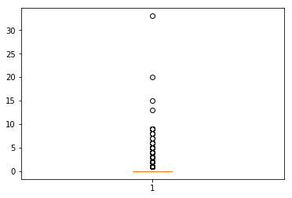

```python
plt.boxplot(loans['InvestmentFromFriendsCount']);
```

> The initial idea was to assess how having friends among lenders would influence default behavior, but as we can see from the plots and outputs above, too few listings actually fall into this category (only 26 listings had 5 or more friends funding it and the boxplot shows that most are considered outliers), so we'll change the scope of this analysis.

### Dist of Loan Status

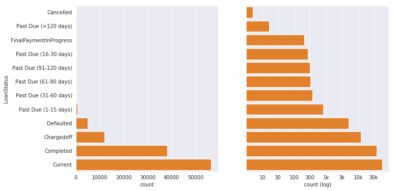

```python
col_color = sb.color_palette()[1]
with sb.axes_style('darkgrid'):
    plt.subplots(1,2, sharey=True, figsize=[11,6])

    plt.subplot(1,2,1)
    sb.countplot(y=loans.LoanStatus, color=col_color)

    plt.subplot(1,2,2)
    sb.countplot(y=loans.LoanStatus, color=col_color)
    plt.xscale('log')
    x_locs = [10, 30, 100, 300, 1000, 3000, 10000, 30000]
    x_labels = [10, 30, 100, 300, '1k', '3k', '10k', '30k']
    plt.xticks(x_locs, x_labels)
    plt.yticks([])
    plt.ylabel('')
    plt.xlabel('count (log)');
```

> The main loan status categories are Defaulted, Chargedoff, Completed and Current. The remaining ones are proportionately irrelevant and we even needed a log scale on count to be able to visualize them.
> - We'll check later how other features affect the default and chargedoff statuses.

### Loan Term dist

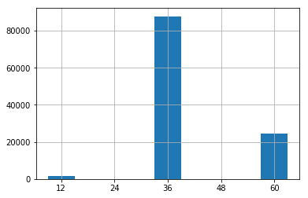

```python
bins = np.arange(9, 60+6, 6)
loans.Term.hist(bins=bins)
ticks = np.arange(12, 60+12, 12)
plt.xticks(ticks, ticks);
```

```python
loans.Term.value_counts()
```

```
36    87778
60    24545
12     1614
Name: Term, dtype: int64
```

> The hist showed counts on too few values with large counts, so I checked value_counts and there were only 3 terms on the listings. Either those are the only term options on Proper's listing system or the dataset specifically selected these 3 terms.

### Debt to Income ratio dist

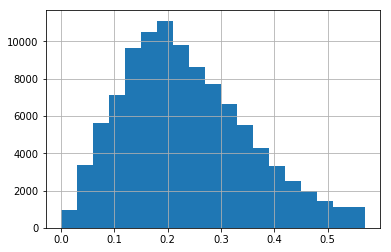

```python
bins = np.arange(0,0.6,0.03)  # bins are already limiting the buckets shown, so no need for xlim
loans.DebtToIncomeRatio.hist(bins=bins)
#plt.xlim(-0.05,1) # focus on where the majority of values are
```

jump to LoanStatus x DebtToIncomeRatio

```python
loans.DebtToIncomeRatio.describe()
```

```
count    105383.000000
mean          0.275947
std           0.551759
min           0.000000
25%           0.140000
50%           0.220000
75%           0.320000
max          10.010000
Name: DebtToIncomeRatio, dtype: float64
```

```
(-0.1, 1)
```

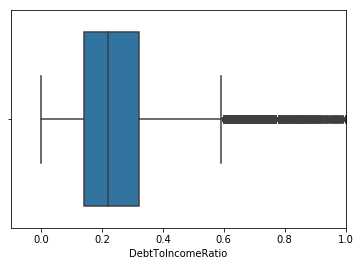

```python
sb.boxplot(loans.DebtToIncomeRatio)
plt.xlim(-0.1,1)
```

> Debt to Income Ratio is concentrated between 0.1 and 0.35 and skewed to the right. I expect a negative correlation between this ratio and the PercentageFunded, as well as BorrowerAPR. Check below for DebtToIncome x LoanStatus.

### Income Range dist

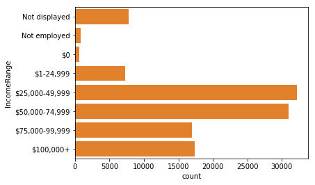

```python
sb.countplot(y=loans['IncomeRange'], color=col_color)
```

> Most common Borrower income ranges are `$25k-50k` and `$50k-75k`

### Listing category dist

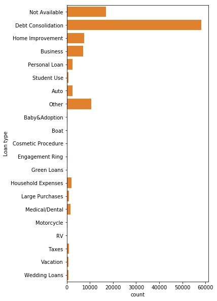

```python
plt.figure(figsize=[5,10])
bins = np.arange(-0.5,21.5,1)
sb.countplot(y=loans['ListingCategory (numeric)'], color=col_color)
labels = ['Not Available', 'Debt Consolidation', 'Home Improvement',
          'Business', 'Personal Loan', 'Student Use', 'Auto',
          'Other', 'Baby&Adoption', 'Boat', 'Cosmetic Procedure',
          'Engagement Ring', 'Green Loans', 'Household Expenses',
          'Large Purchases', 'Medical/Dental', 'Motorcycle', 'RV',
          'Taxes', 'Vacation', 'Wedding Loans']
y_ticks = np.arange(0,21)
plt.yticks(y_ticks, labels)
plt.ylabel('Loan type');
```

> Debt consolidation is by far the most requested type of loan, approaching a count of 60k

### Quick look on Loan Amounts

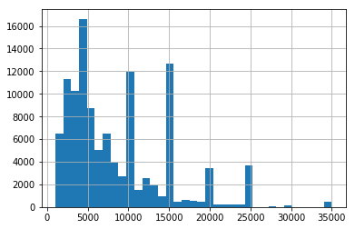

```python
loans['LoanOriginalAmount'].hist(bins=35)
```

> The loan amounts are concentrated on smaller amounts between 1k and 6k, with peaks at multiples of 5k.

### Dist of Employment Status

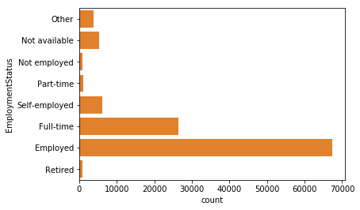

```python
sb.countplot(y=loans['EmploymentStatus'], color=col_color)
```

> Most of the Borrowers have declared to be either Employed or Full-time, which seems to be confusing (part-time and full-time could be part of the bigger category 'employed', but here they are each different categories themselves)

### Discuss the distribution(s) of your variable(s) of interest. Were there any unusual points? Did you need to perform any transformations?

> It was unusual to find out that a significant part of the loans was taken for debt consolidation purposes. In other words, borrowers were refinancing existing debts rather than borrowing for new projects or expenses.

> Transformation (to log scale) was needed only for PercentFund and LoanStatus, since the count was highly concentrated on a few categories.

### Of the features you investigated, were there any unusual distributions? Did you perform any operations on the data to tidy, adjust, or change the form of the data? If so, why did you do this?

> I had perform operations to change data types for datetime columns and also to a few of the categorical variables in order to allow further investigation of these variables later. Log scales was used for better visualization as explained on the answer right above.

## Bivariate Exploration

> In this section, investigate relationships between pairs of variables in your data. Make sure the variables that you cover here have been introduced in some fashion in the previous section (univariate exploration).

### LoanStatus x DebtToIncomeRatio

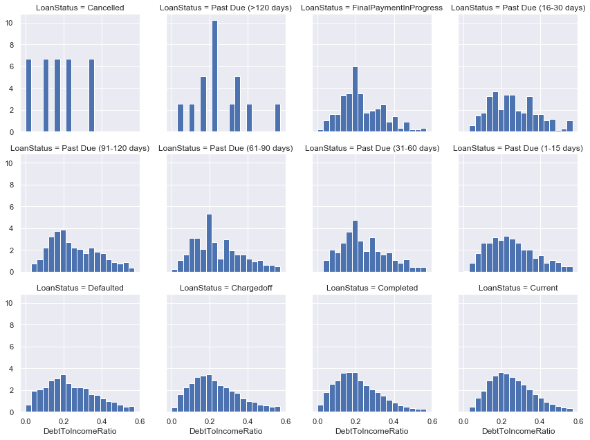

```python
# LoanStatus vs DebtToIncomeRatio

"""
with sb.axes_style('whitegrid'):
    plt.figure(figsize=[5,10])
    sb.violinplot(data=loans, x='DebtToIncomeRatio', y='LoanStatus', color=col_color)
    plt.xlim(0,0.4) # zooming on majority of values"""

sb.set('notebook')
g = sb.FacetGrid(data=loans, col='LoanStatus', col_wrap=4)
bins = np.arange(0,0.6,0.03) # so that bars fall on the center of round values
g.map(plt.hist, 'DebtToIncomeRatio', bins=bins, density=True) # density parameter to normalize LoanStatus counts
#g.set(yscale='log')
```

> The bottom row distributions all look quite similar, which could be an indicator that DebtToIncome ratio may not be such a good predictor that a Borrower will default. They are also similar to the general Debt to Income dist we observed when doing univariate exploration. Interesting to notice that on most of the histograms, the 0.2 ratio is the mode.

### DebtToIncomeRatio x BorrowerAPR

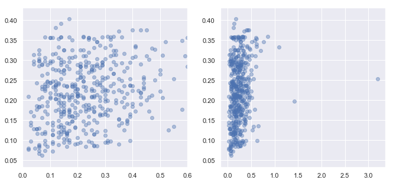

```python
loan_sample = loans.sample(500)
plt.subplots(1,2, figsize=[11,5])

plt.subplot(1,2,1)
plt.scatter(data=loan_sample, x='DebtToIncomeRatio', y='BorrowerAPR', alpha=0.4)
plt.xlim(0,0.6) # zoom on where dots are concentrated
#plt.plot([0.26, 0.8], [0.05, 0.3], c='g')

plt.subplot(1,2,2)
plt.scatter(data=loan_sample, x='DebtToIncomeRatio', y='BorrowerAPR', alpha=0.4)
```

> Apparently there's no strong correlation between the ratio and the borrowing rate, at least up until a 0.3 ratio, after which we can observe an upwards trend.

### How does employment status affect your borrowing rate?

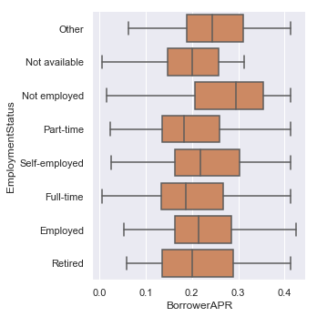

```python
cat_color = sb.color_palette()[1]
sb.catplot(data=loans, y='EmploymentStatus', x='BorrowerAPR', kind='box', color=cat_color)
```

> As expected, the mean, q1 and q3 for Not Employed are higher than for those Employed. What surprised me was that min and max are lower for Not Employed than for Employed, which seems a bit odd. Even Part-time have better summary stats than Employed. The reason for this could be that Employed has the biggest count of all categories, while part-time and Not Employed are much less representative as we could see previously on the Employment status dist.

### Does Borrower income range affect one's default rate?

```python
# counts for categories of interest

counts = loans.groupby(['LoanStatus', 'IncomeRange']).size()
counts = counts.reset_index(name='count')
counts = counts.pivot(index='LoanStatus', columns = 'IncomeRange', values='count')
```

```python
counts
```

| IncomeRange LoanStatus | Not displayed | Not employed | $0 | $1-24,999 | $25,000-49,999 | $50,000-74,999 | $75,000-99,999 | $100,000+ |
| --- | --- | --- | --- | --- | --- | --- | --- | --- |
| Cancelled | 4.0 | NaN | NaN | NaN | 1.0 | NaN | NaN | NaN |
| Past Due (>120 days) | NaN | NaN | 1.0 | NaN | 7.0 | 7.0 | 1.0 | NaN |
| FinalPaymentInProgress | NaN | NaN | NaN | 14.0 | 49.0 | 64.0 | 26.0 | 52.0 |
| Past Due (16-30 days) | NaN | 5.0 | NaN | 20.0 | 80.0 | 83.0 | 37.0 | 40.0 |
| Past Due (91-120 days) | NaN | 3.0 | NaN | 27.0 | 114.0 | 99.0 | 33.0 | 28.0 |
| Past Due (61-90 days) | NaN | 6.0 | 1.0 | 22.0 | 102.0 | 92.0 | 52.0 | 38.0 |
| Past Due (31-60 days) | NaN | 3.0 | NaN | 32.0 | 119.0 | 89.0 | 55.0 | 65.0 |
| Past Due (1-15 days) | NaN | 9.0 | 2.0 | 52.0 | 266.0 | 212.0 | 131.0 | 134.0 |
| Defaulted | 1747.0 | 25.0 | 51.0 | 334.0 | 1290.0 | 874.0 | 375.0 | 322.0 |
| Chargedoff | 1380.0 | 182.0 | 185.0 | 1329.0 | 4162.0 | 2633.0 | 1153.0 | 968.0 |
| Completed | 4610.0 | 325.0 | 370.0 | 2908.0 | 10891.0 | 9282.0 | 4914.0 | 4774.0 |
| Current | NaN | 248.0 | 11.0 | 2536.0 | 15111.0 | 17615.0 | 10139.0 | 10916.0 |

```python
# turn them into proportions
props = counts / counts.sum()
```

```python
# checking column proportion sum to 1
props.sum()
```

```
IncomeRange
Not displayed     1.0
Not employed      1.0
$0                1.0
$1-24,999         1.0
$25,000-49,999    1.0
$50,000-74,999    1.0
$75,000-99,999    1.0
$100,000+         1.0
dtype: float64
```

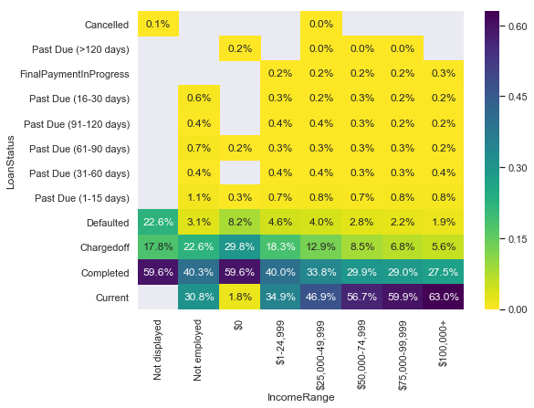

```python
plt.figure(figsize=[8,6])
sb.heatmap(props, annot=True, cmap='viridis_r', fmt='.1%')
```

> The heatmap shows that the income ranges with highest *default* rates are `Not displayed` and `$0`, while ranges with highest *chargedoff* rates are once again `$0` and `Not employed`. **As a general rule, on this dataset, the higher the *income range*, the lower the *default* and *chargedoff* rates are.**

### Verifying relation between BorrowerAPR and DelinquenciesLast7Years

```
(-1, 20)
```

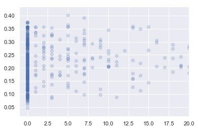

```python
plt.scatter(y='BorrowerAPR', x='DelinquenciesLast7Years', data=loan_sample, alpha=0.2)
plt.xlim(-1,20)
```

> Apparently nothing meaningful here. Most data points are on 0 delinquencies, meaning most borrowers have had no delinquencies in the past 7 years.

### What variables are related to higher interest rates to the Borrower?

```python
# reduce influence of variable DebtToIncome
loan_debt20perc = loans[(loans.DebtToIncomeRatio > 0.18) & (loans.DebtToIncomeRatio < 0.22)]
```

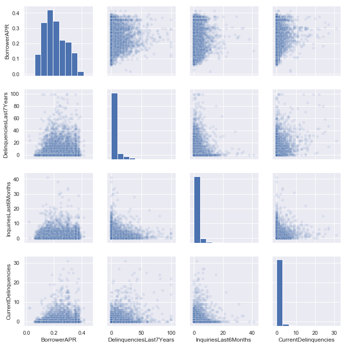

```python
num_vars = ['BorrowerAPR','DelinquenciesLast7Years',
            'InquiriesLast6Months','CurrentDelinquencies']
sb.pairplot(data=loan_debt20perc, vars=num_vars, plot_kws={'alpha': 1/10})
```

```python
loans.OpenCreditLines.describe()
```

```
count    106333.000000
mean          9.260164
std           5.022644
min           0.000000
25%           6.000000
50%           9.000000
75%          12.000000
max          54.000000
Name: OpenCreditLines, dtype: float64
```

```python
loans.CurrentDelinquencies.corr(loans.BorrowerAPR)
```

```
0.14940393564399254
```

```python
loans.InquiriesLast6Months.corr(loans.BorrowerAPR)
```

```
0.14611930770966458
```

> It seems that InquiriesLast6Months and CurrentDelinquencies could have some correlation to higher values of BorrowerAPR, since the chart apparently shows that higher values in these variables push the BorrowerAPR up. When computed, Pearson's $r$ for both rank at 0.14. For a prediction model, I'd probably pick these as secondary predictors, though I'd still be on the look for primary predictors.

### Talk about some of the relationships you observed in this part of the investigation. How did the feature(s) of interest vary with other features in the dataset?

> To my surprise, I learned that the DebtToIncome ratio shows no strong signs of correlation to neither BorrowerAPR nor (default/chargedoff) rates (*LoanStatus* categories). The visualizations created also let us observe that the borrower's employment status plays a part in the loan interest rate and the borrower's income range is somewhat correlated to the default and chargedoff proportions (the higher the income range, the lower the default and chargedoff proportions).

### Did you observe any interesting relationships between the other features (not the main feature(s) of interest)?

> Not really.

## Multivariate Exploration

> Create plots of three or more variables to investigate your data even further. Make sure that your investigations are justified, and follow from your work in the previous sections.

### Does it make a diference on your borrowing rate if you're a homeowner?

```python
loan_sample.IsBorrowerHomeowner.head()
```

```
71202      True
17629     False
30806      True
32023     False
110880    False
Name: IsBorrowerHomeowner, dtype: bool
```

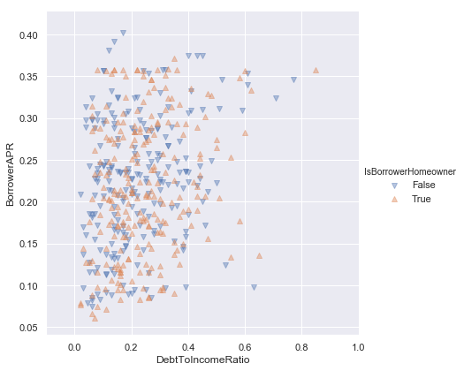

```python
g = sb.FacetGrid(data=loan_sample, hue='IsBorrowerHomeowner',
             hue_kws=dict(marker=["v", "^"]), height=6)
g.map(plt.scatter, 'DebtToIncomeRatio', 'BorrowerAPR',alpha=0.4)
g.set(xlim=[-0.1,1]) # zoom on where data points are concentrated
g.add_legend()
```

> From the plot, it appears to have no effect on the BorrowerAPR whether you are a homeowner or not, since the data points of both marker colors don't seem to follow any particular pattern.

```python
loans['ListingCategory (numeric)'].describe()
```

```
count    113937.000000
mean          2.774209
std           3.996797
min           0.000000
25%           1.000000
50%           1.000000
75%           3.000000
max          20.000000
Name: ListingCategory (numeric), dtype: float64
```

### BorrowerAPR, DebtToIncome and IncomeRange

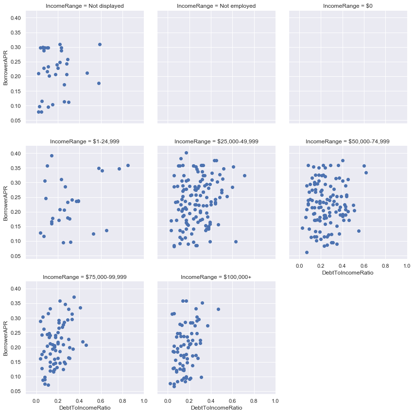

```python
# sample only, to avoid flooding the scatter
g = sb.FacetGrid(data=loan_sample, col='IncomeRange', xlim=[-0.1,1], height=4, col_wrap=3)
g.map(plt.scatter, 'DebtToIncomeRatio', 'BorrowerAPR')
```

> It seems that points tend to gradually concentrate on the lower quadrant of each facet (lower APR and lower debt ratio) the higher the income range gets. We should confirm if that holds true for the same debt ratio across Income ranges.

### Controlling for debt ratio

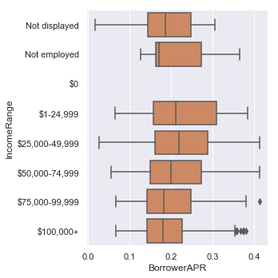

```python
# Checking influence of IncomeRange for the same debt ratio
loan_debt20perc = loans[loans.DebtToIncomeRatio == 0.2]
sb.catplot(data=loan_debt20perc, y='IncomeRange', x='BorrowerAPR', kind='box', color=cat_color)
```

```python
# checking size of this debt ratio to make sure it is not too small a sample.
# 0.2 is the mode debt ratio in the dataset
loan_debt20perc.shape
```

```
(3481, 81)
```

> We can notice from the charts above that the DebtToIncomeRatio appears to reduce on higher IncomeRanges and the APR is also lower for higher incomes. It seems that the higher your IncomeRange, the less interest you're likely to pay when you borrow on Prosper. That makes sense, given our previous observation that higher income ranges have lower default and chargedoff rates, although it may not make too much sense socially.
> - Could the higher interest itself be correlated to higher default rates?

### Would lower interest equalize default and chargedoff rates across Income ranges?

```python
# so let's control this variable and select only lower interest loans
# low_int_loans = loans[(loans.BorrowerAPR < 0.13) & (loans.DebtToIncomeRatio < 0.2)]
low_int_loans = loans[loans.BorrowerAPR < 0.13]
```

```python
low_int_loans.shape
```

```
(16333, 81)
```

```python
# counts for categories of interest

counts = low_int_loans.groupby(['LoanStatus', 'IncomeRange']).size()
counts = counts.reset_index(name='count')
counts = counts.pivot(index='LoanStatus', columns = 'IncomeRange', values='count')
```

```python
counts
```

| IncomeRange LoanStatus | Not displayed | Not employed | $0 | $1-24,999 | $25,000-49,999 | $50,000-74,999 | $75,000-99,999 | $100,000+ |
| --- | --- | --- | --- | --- | --- | --- | --- | --- |
| FinalPaymentInProgress | NaN | NaN | NaN | 1.0 | 4.0 | 9.0 | 4.0 | 10.0 |
| Past Due (16-30 days) | NaN | NaN | NaN | NaN | NaN | 1.0 | 1.0 | 2.0 |
| Past Due (91-120 days) | NaN | NaN | NaN | NaN | 1.0 | 6.0 | 1.0 | NaN |
| Past Due (61-90 days) | NaN | NaN | NaN | 1.0 | 1.0 | 1.0 | 2.0 | 1.0 |
| Past Due (31-60 days) | NaN | NaN | NaN | NaN | 3.0 | 2.0 | 2.0 | 5.0 |
| Past Due (1-15 days) | NaN | NaN | NaN | 1.0 | 5.0 | 3.0 | 8.0 | 4.0 |
| Defaulted | 94.0 | 2.0 | 4.0 | 23.0 | 97.0 | 71.0 | 42.0 | 36.0 |
| Chargedoff | 82.0 | 2.0 | 10.0 | 58.0 | 215.0 | 179.0 | 85.0 | 89.0 |
| Completed | 1383.0 | 44.0 | 86.0 | 527.0 | 2113.0 | 2049.0 | 1314.0 | 1465.0 |
| Current | NaN | 6.0 | NaN | 92.0 | 886.0 | 1873.0 | 1361.0 | 1966.0 |

```python
# turn them into proportions
props = counts / counts.sum()
```

```python
# checking column proportion sum to 1
props.sum()
```

```
IncomeRange
Not displayed     1.0
Not employed      1.0
$0                1.0
$1-24,999         1.0
$25,000-49,999    1.0
$50,000-74,999    1.0
$75,000-99,999    1.0
$100,000+         1.0
dtype: float64
```

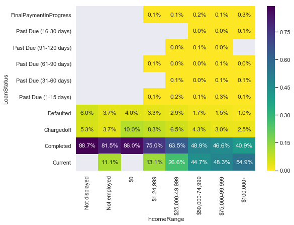

```python
plt.figure(figsize=[8,6])
sb.heatmap(props, annot=True, cmap='viridis_r', fmt='.1%')
```

> Even when controlling for BorrowerAPR variable, we still notice the same trend as previously: the higher the Income Range, the lower the default and chargedoff rates.

### BorrowerAPR x EmploymentStatusDuration x IncomeRange

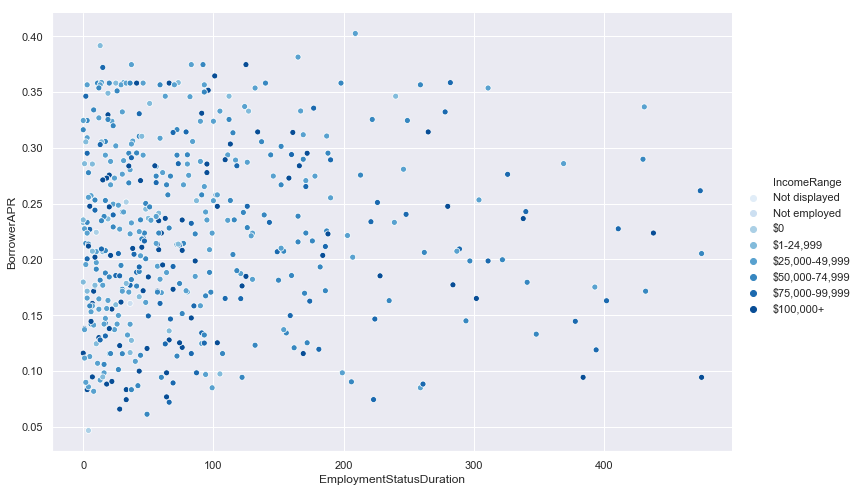

```python
sb.relplot(data=loan_sample, x='EmploymentStatusDuration', y='BorrowerAPR', hue='IncomeRange',
           palette='Blues', height=7, aspect=1.5)
```

> Data points are quite spread on the plot above, so I'm afraid it doesn't convey any useful pattern. The only thing we notice is that most people who borrow have less than 200 (about 16.6 years) months of employment, but no apparent relation or influence on BorrowerAPR. Also, the color code for IncomeRange doesn't help much.

### How about trends within defaulted and chargedoff loans?

```python
# controlling for Debt ratio among defaulted loans
failed_loans = (loan_debt20perc[loan_debt20perc.LoanStatus.isin(['Defaulted', 'Chargedoff'])])
```

```python
failed_loans.shape
```

```
(468, 81)
```

```python
loans.columns
```

```
Index(['ListingKey', 'ListingNumber', 'ListingCreationDate', 'CreditGrade',
       'Term', 'LoanStatus', 'ClosedDate', 'BorrowerAPR', 'BorrowerRate',
       'LenderYield', 'EstimatedEffectiveYield', 'EstimatedLoss',
       'EstimatedReturn', 'ProsperRating (numeric)', 'ProsperRating (Alpha)',
       'ProsperScore', 'ListingCategory (numeric)', 'BorrowerState',
       'Occupation', 'EmploymentStatus', 'EmploymentStatusDuration',
       'IsBorrowerHomeowner', 'CurrentlyInGroup', 'GroupKey',
       'DateCreditPulled', 'CreditScoreRangeLower', 'CreditScoreRangeUpper',
       'FirstRecordedCreditLine', 'CurrentCreditLines', 'OpenCreditLines',
       'TotalCreditLinespast7years', 'OpenRevolvingAccounts',
       'OpenRevolvingMonthlyPayment', 'InquiriesLast6Months', 'TotalInquiries',
       'CurrentDelinquencies', 'AmountDelinquent', 'DelinquenciesLast7Years',
       'PublicRecordsLast10Years', 'PublicRecordsLast12Months',
       'RevolvingCreditBalance', 'BankcardUtilization',
       'AvailableBankcardCredit', 'TotalTrades',
       'TradesNeverDelinquent (percentage)', 'TradesOpenedLast6Months',
       'DebtToIncomeRatio', 'IncomeRange', 'IncomeVerifiable',
       'StatedMonthlyIncome', 'LoanKey', 'TotalProsperLoans',
       'TotalProsperPaymentsBilled', 'OnTimeProsperPayments',
       'ProsperPaymentsLessThanOneMonthLate',
       'ProsperPaymentsOneMonthPlusLate', 'ProsperPrincipalBorrowed',
       'ProsperPrincipalOutstanding', 'ScorexChangeAtTimeOfListing',
       'LoanCurrentDaysDelinquent', 'LoanFirstDefaultedCycleNumber',
       'LoanMonthsSinceOrigination', 'LoanNumber', 'LoanOriginalAmount',
       'LoanOriginationDate', 'LoanOriginationQuarter', 'MemberKey',
       'MonthlyLoanPayment', 'LP_CustomerPayments',
       'LP_CustomerPrincipalPayments', 'LP_InterestandFees', 'LP_ServiceFees',
       'LP_CollectionFees', 'LP_GrossPrincipalLoss', 'LP_NetPrincipalLoss',
       'LP_NonPrincipalRecoverypayments', 'PercentFunded', 'Recommendations',
       'InvestmentFromFriendsCount', 'InvestmentFromFriendsAmount',
       'Investors'],
      dtype='object')
```

```python
num_vars = ['BorrowerAPR','DelinquenciesLast7Years',
            'InquiriesLast6Months','CurrentDelinquencies']
```

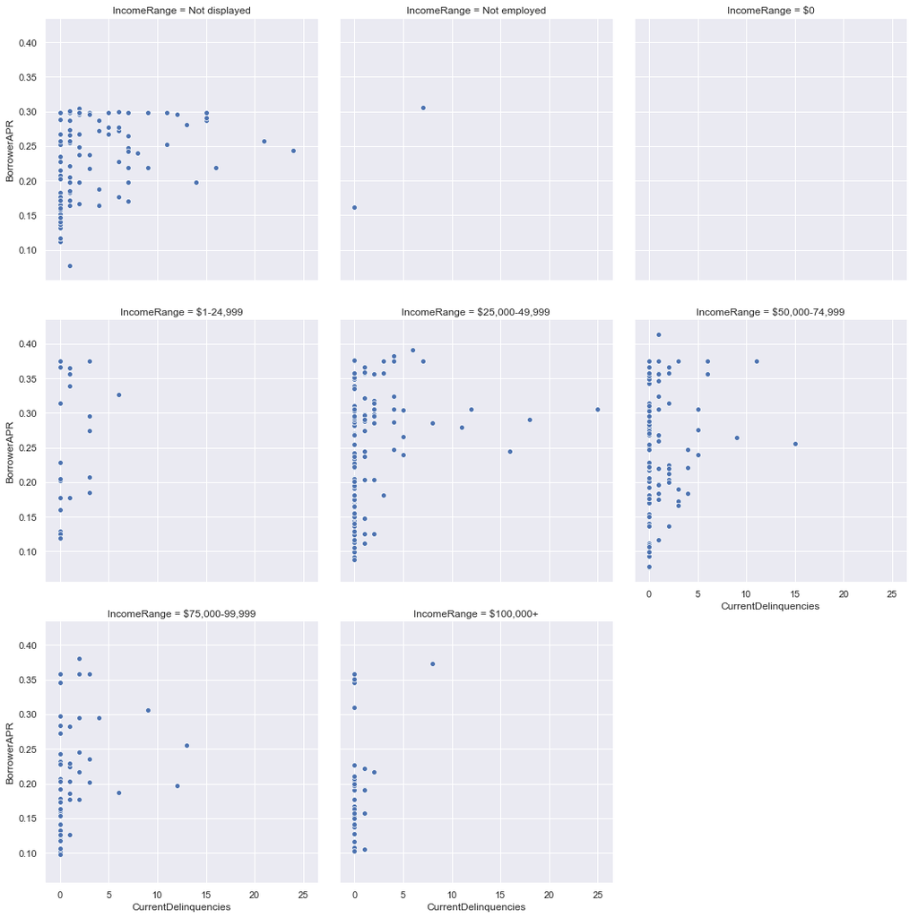

```python
sb.relplot(data=failed_loans, col='IncomeRange', col_wrap=3, y='BorrowerAPR', x='CurrentDelinquencies')
```

> No distinguishable pattern, but we see that having No CurrentDelinquencies does not assure a Borrower will get a good APR, so there's probably a number of credit history factors taken into play (polinomial?) when determining the APR for a loan.

### Were there any interesting or surprising interactions between features?

> I had no idea that Income would play such an important part in BorrowerAPR. Initially, I thought that controlling for other variables that are expressed in proportions or percentages would eventually show that Income was in fact not important at all. It seems I was wrong. Although the Debt ratio tends to be higher for lower income borrowers, I decided to observe boxplots for each income range when all the ranges share the same debt ratio. Still, the summary stats for BorrowerAPR was lower for higher income borrowers.

> Then I decided to tackle a possible APR rate bias. My line of thought was: maybe lower income borrowers just default more because they're charged higher rates, so they struggle because of the rate itself. So I selected only loans with lower interest rates, but still got the same trend.

> Given all that, this work cannot make conclusions about causation, because none of the correlations shown here imply such a relation. We can simply say that the likelihood for default and charge-off is lower as your Income range increases and we can only speculate on the reasons that happens, but not categorically say we were able to determine them, as that would require controlled testing and a whole other approach.